# Assignment

Pegah Yazdkhasti

January 31, 2016

The first step is to load the csv file to get training and testing data with the ‘calasse’ parameter as the outcome:

```r
#quick summary
library(caret)
library(ggplot2)
mydata <- read.csv("pml-training.csv")

inTrain <- createDataPartition(y=mydata$classe, p=0.75, list=FALSE)

training <- mydata[inTrain,]
testing <- mydata[-inTrain,]
```

Now using near zero variables pre-processing tools, the irrelavant variables can be determined:

```r
nsv <- nearZeroVar(training , saveMetrics=TRUE)
nsv
```

```
##                            freqRatio percentUnique zeroVar   nzv
## X                           1.000000  100.00000000   FALSE FALSE
## user_name                   1.102814    0.04076641   FALSE FALSE
## raw_timestamp_part_1        1.033333    5.68011958   FALSE FALSE
## raw_timestamp_part_2        1.000000   88.74167686   FALSE FALSE
## cvtd_timestamp              1.007240    0.13588803   FALSE FALSE
## new_window                 47.255738    0.01358880   FALSE  TRUE
## num_window                  1.033333    5.81600761   FALSE FALSE
## roll_belt                   1.148545    7.66408479   FALSE FALSE
## pitch_belt                  1.148936   11.52330480   FALSE FALSE
## yaw_belt                    1.177778   12.49490420   FALSE FALSE
## total_accel_belt            1.058249    0.19703764   FALSE FALSE
## kurtosis_roll_belt       2402.166667    2.03832042   FALSE  TRUE
## kurtosis_picth_belt       626.652174    1.67821715   FALSE  TRUE
## kurtosis_yaw_belt          47.255738    0.01358880   FALSE  TRUE
## skewness_roll_belt       2402.166667    2.02473162   FALSE  TRUE
## skewness_roll_belt.1      626.652174    1.77333877   FALSE  TRUE
## skewness_yaw_belt          47.255738    0.01358880   FALSE  TRUE
## max_roll_belt               1.125000    1.13466504   FALSE FALSE
## max_picth_belt              1.813953    0.14268243   FALSE FALSE
## max_yaw_belt              600.541667    0.40086968   FALSE  TRUE
## min_roll_belt               1.250000    1.05992662   FALSE FALSE
## min_pitch_belt              2.333333    0.10191602   FALSE FALSE
## min_yaw_belt              600.541667    0.40086968   FALSE  TRUE
## amplitude_roll_belt         1.190476    0.83571137   FALSE FALSE
## amplitude_pitch_belt        3.395833    0.08153282   FALSE FALSE
## amplitude_yaw_belt         48.204013    0.02038320   FALSE  TRUE
## var_total_accel_belt        1.475410    0.38728088   FALSE FALSE
## avg_roll_belt               1.090909    1.12787063   FALSE FALSE
## stddev_roll_belt            1.162162    0.41445849   FALSE FALSE
## var_roll_belt               1.764706    0.55034651   FALSE FALSE
## avg_pitch_belt              1.142857    1.27734747   FALSE FALSE
## stddev_pitch_belt           1.040816    0.27177606   FALSE FALSE
## var_pitch_belt              1.123288    0.37369208   FALSE FALSE
## avg_yaw_belt                1.000000    1.35208588   FALSE FALSE
## stddev_yaw_belt             1.621622    0.33292567   FALSE FALSE
## var_yaw_belt                1.303030    0.82212257   FALSE FALSE
## gyros_belt_x                1.045675    0.92403859   FALSE FALSE
## gyros_belt_y                1.128960    0.44163609   FALSE FALSE
## gyros_belt_z                1.026667    1.10069303   FALSE FALSE
```

[output cut: 106 more lines]

```
## stddev_pitch_forearm       60.000000    1.67142275   FALSE  TRUE
## var_pitch_forearm          60.000000    1.67142275   FALSE  TRUE
## avg_yaw_forearm            60.000000    1.67142275   FALSE  TRUE
## stddev_yaw_forearm         60.000000    1.67142275   FALSE  TRUE
## var_yaw_forearm            60.000000    1.67142275   FALSE  TRUE
## gyros_forearm_x             1.073418    1.94319880   FALSE FALSE
## gyros_forearm_y             1.027304    4.90555782   FALSE FALSE
## gyros_forearm_z             1.102703    1.99755402   FALSE FALSE
## accel_forearm_x             1.166667    5.33360511   FALSE FALSE
## accel_forearm_y             1.036145    6.67889659   FALSE FALSE
## accel_forearm_z             1.105263    3.79807039   FALSE FALSE
## magnet_forearm_x            1.142857    9.86547085   FALSE FALSE
## magnet_forearm_y            1.200000   12.50849300   FALSE FALSE
## magnet_forearm_z            1.045455   11.04090230   FALSE FALSE
## classe                      1.469452    0.03397201   FALSE FALSE
```

The variables whose ‘nzv’ parameter is TRUE have no impact on the outcome and thus they can be removed from the data.

The username and time (basically the first 7 columns) also have no impact on the outcome; therefore, in addition to the ‘nzv’ variables, these columns can also be omitted.

The resulting data set is stored in a new ‘csv’ file called ‘reduced.csv’ and from now on, this file will be used as the primary input data. The training and testing sets will be created from this data file:

```r
mydata = read.csv("reduced.csv")
inTrain = createDataPartition(y=mydata$classe, p=0.75, list=FALSE)

training <- mydata[inTrain,]
testing <- mydata[-inTrain,]
```

Relationship between the ‘classe’ outcome and different variables can be observed through featurePlot function:

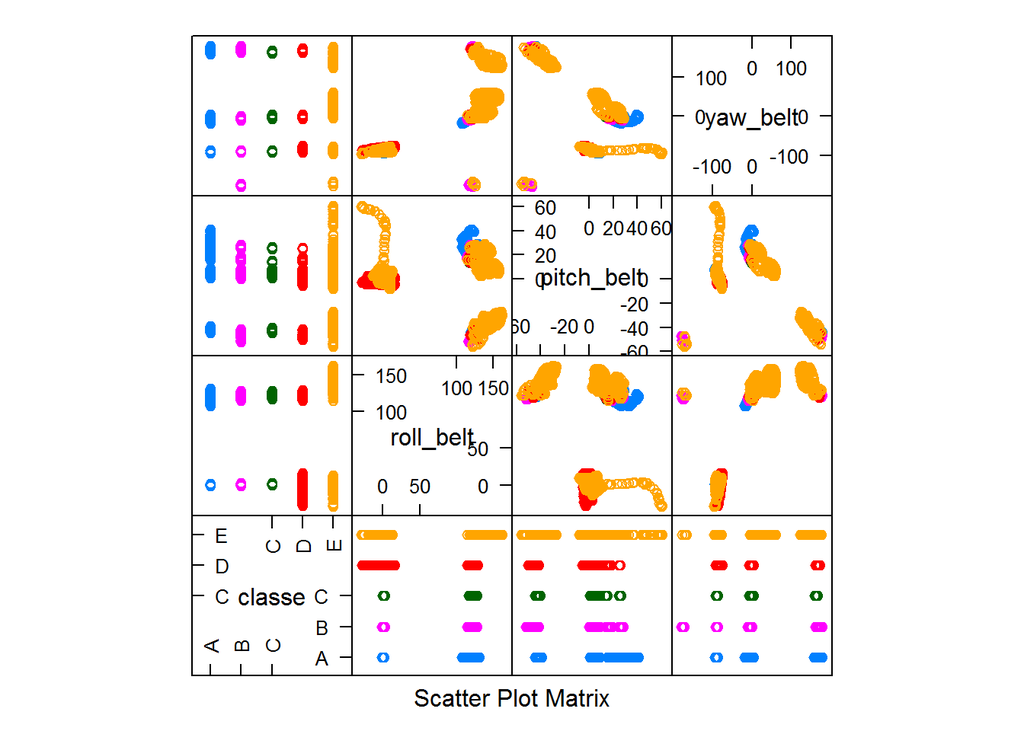

```r
featurePlot(x=training[,c("classe","roll_belt","pitch_belt","yaw_belt")],y=training$classe, plot="pairs")
```

This example shows how the ‘classe’ may depend on ‘roll belt’,‘pitch belt’ or ‘yaw belt’.

Now, a model can be created with all the reduced paramters using the ‘train’ function with ‘random forest’ method.

```r
modFit <- train(classe ~ .,method = "rf",data = training)
modFit
```

```
## Random Forest
##
## 14718 samples
##    52 predictor
##     5 classes: 'A', 'B', 'C', 'D', 'E'
##
## No pre-processing
## Resampling: Bootstrapped (25 reps)
## Summary of sample sizes: 14718, 14718, 14718, 14718, 14718, 14718, ...
## Resampling results across tuning parameters:
##
##   mtry  Accuracy   Kappa      Accuracy SD  Kappa SD
##    2    0.9892783  0.9864333  0.001460534  0.001849827
##   27    0.9893156  0.9864808  0.001613144  0.002039457
##   52    0.9824358  0.9777751  0.005022514  0.006355704
##
## Accuracy was used to select the optimal model using  the largest value.
## The final value used for the model was mtry = 27.
```

Using this model to predict the outcome on the testing set will result in:

```r
prediction <- predict(modFit , newdata=testing)

prediction
```

[output not shown]

[output cut: 131 more lines]

where the confusion matrix can be obtained with:

```r
confusionMatrix(prediction, testing$classe)
```

```
## Confusion Matrix and Statistics
##
##           Reference
## Prediction    A    B    C    D    E
##          A 1394    8    0    0    0
##          B    1  940    2    0    0
##          C    0    1  849    5    3
##          D    0    0    4  797    1
##          E    0    0    0    2  897
##
## Overall Statistics
##
##                Accuracy : 0.9945
##                  95% CI : (0.992, 0.9964)
##     No Information Rate : 0.2845
##     P-Value [Acc > NIR] : < 2.2e-16
##
##                   Kappa : 0.993
##  Mcnemar's Test P-Value : NA
##
## Statistics by Class:
##
##                      Class: A Class: B Class: C Class: D Class: E
## Sensitivity            0.9993   0.9905   0.9930   0.9913   0.9956
## Specificity            0.9977   0.9992   0.9978   0.9988   0.9995
## Pos Pred Value         0.9943   0.9968   0.9895   0.9938   0.9978
## Neg Pred Value         0.9997   0.9977   0.9985   0.9983   0.9990
## Prevalence             0.2845   0.1935   0.1743   0.1639   0.1837
## Detection Rate         0.2843   0.1917   0.1731   0.1625   0.1829
## Detection Prevalence   0.2859   0.1923   0.1750   0.1635   0.1833
## Balanced Accuracy      0.9985   0.9949   0.9954   0.9950   0.9975
```

Since the result is good, we can run this model on the final test data. To do this, first we should load the test data, then apply the predict function on the data and print the result:

```r
runData  <- read.csv("pml-testing.csv")
result <- predict(modFit , newdata=runData  )

result
```

```
##  [1] B A B A A E D B A A B C B A E E A B B B
## Levels: A B C D E
```